# NYDP Shooting Incident Data

```r
library(tidyverse)
library(lubridate)
library(dplyr)
library(class)
library(caret)
```

## Project Step 2: Tidy and Transform Your Data & Project Step 3: Add Visualizations and Analysis

For analyze shooting incident time distribution, We need to convert date to month and time to hours

```r
shoot <- read_csv("https://data.cityofnewyork.us/api/views/833y-fsy8/rows.csv?accessType=DOWNLOAD")
summary(shoot)
```

```
##   INCIDENT_KEY        OCCUR_DATE         OCCUR_TIME           BORO
##  Min.   :  9953245   Length:28562       Length:28562      Length:28562
##  1st Qu.: 65439914   Class :character   Class1:hms        Class :character
##  Median : 92711254   Mode  :character   Class2:difftime   Mode  :character
##  Mean   :127405824                      Mode  :numeric
##  3rd Qu.:203131993
##  Max.   :279758069
##
##  LOC_OF_OCCUR_DESC     PRECINCT     JURISDICTION_CODE LOC_CLASSFCTN_DESC
##  Length:28562       Min.   :  1.0   Min.   :0.0000    Length:28562
##  Class :character   1st Qu.: 44.0   1st Qu.:0.0000    Class :character
##  Mode  :character   Median : 67.0   Median :0.0000    Mode  :character
##                     Mean   : 65.5   Mean   :0.3219
##                     3rd Qu.: 81.0   3rd Qu.:0.0000
##                     Max.   :123.0   Max.   :2.0000
##                                     NA's   :2
##  LOCATION_DESC      STATISTICAL_MURDER_FLAG PERP_AGE_GROUP
##  Length:28562       Mode :logical           Length:28562
##  Class :character   FALSE:23036             Class :character
##  Mode  :character   TRUE :5526              Mode  :character
##
##
##
##
##    PERP_SEX          PERP_RACE         VIC_AGE_GROUP        VIC_SEX
##  Length:28562       Length:28562       Length:28562       Length:28562
##  Class :character   Class :character   Class :character   Class :character
##  Mode  :character   Mode  :character   Mode  :character   Mode  :character
##
##
##
##
##    VIC_RACE           X_COORD_CD        Y_COORD_CD        Latitude
##  Length:28562       Min.   : 914928   Min.   :125757   Min.   :40.51
##  Class :character   1st Qu.:1000068   1st Qu.:182912   1st Qu.:40.67
##  Mode  :character   Median :1007772   Median :194901   Median :40.70
##                     Mean   :1009424   Mean   :208380   Mean   :40.74
##                     3rd Qu.:1016807   3rd Qu.:239814   3rd Qu.:40.82
##                     Max.   :1066815   Max.   :271128   Max.   :40.91
##                                                        NA's   :59
##    Longitude        Lon_Lat
##  Min.   :-74.25   Length:28562
##  1st Qu.:-73.94   Class :character
##  Median :-73.92   Mode  :character
##  Mean   :-73.91
##  3rd Qu.:-73.88
##  Max.   :-73.70
##  NA's   :59
```

The histogram show that the incidents frequently occurred in the evening and night

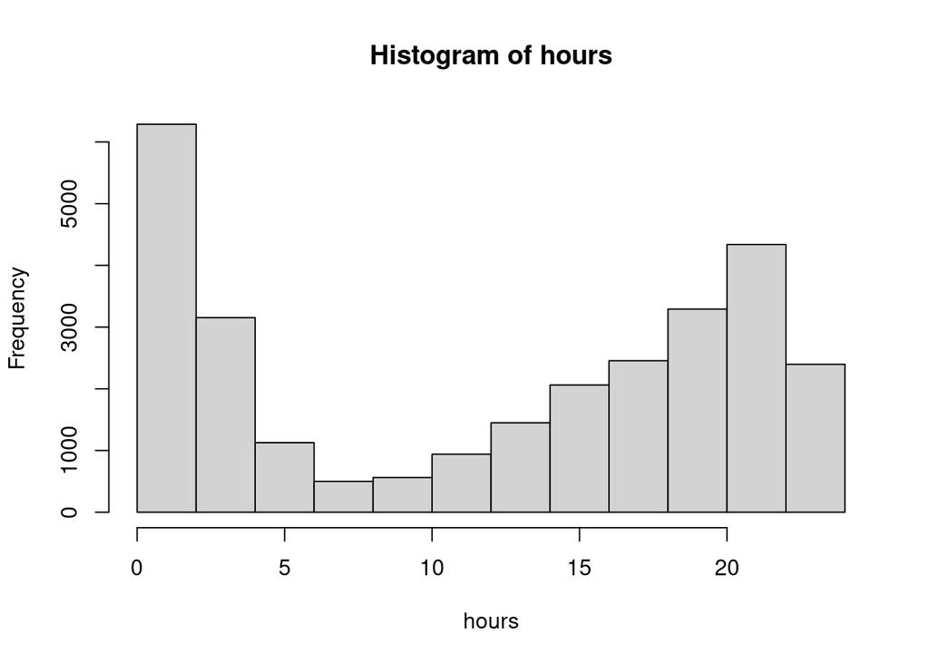

```r
shoot$OCCUR_TIME <- strptime(shoot$OCCUR_TIME, format="%H:%M:%S")
hours <-  as.numeric(format(shoot$OCCUR_TIME, format="%H"))
hist(hours)
```

```r
shoot$OCCUR_TIME <-hours
```

The histogram show that the incidents frequently occurred in the middle of the year(July-August)

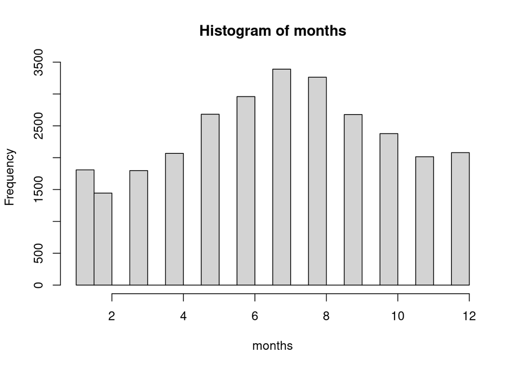

```r
shoot$OCCUR_DATE <- strptime(shoot$OCCUR_DATE, format="%m/%d/%y")
months <-  as.numeric(format(shoot$OCCUR_DATE, format="%m"))
hist(months)
```

```r
shoot$OCCUR_DATE <- months
```

Top Borough where the shooting incident frequently occurred

```r
shoot %>%
  count(BORO, name = "Times", sort = TRUE) %>%
  slice_head(n = 5)
```

```
## # A tibble: 5 × 2
##   BORO          Times
##   <chr>         <int>
## 1 BROOKLYN      11346
## 2 BRONX          8376
## 3 QUEENS         4271
## 4 MANHATTAN      3762
## 5 STATEN ISLAND   807
```

### data modeling

My classes are imbalanced.

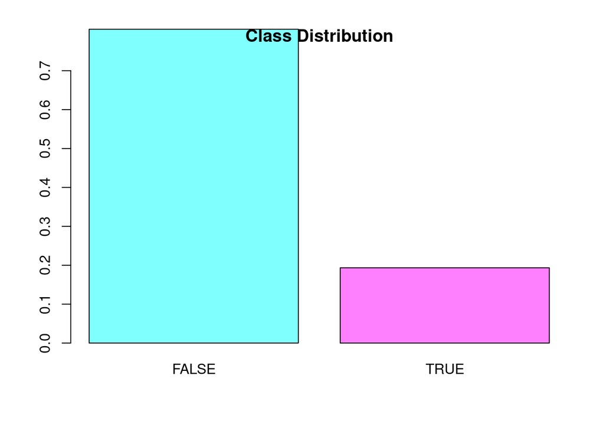

```r
barplot(prop.table(table(shoot$STATISTICAL_MURDER_FLAG)),
        col = cm.colors(2),
        ylim = c(0, 0.7),
        main = "Class Distribution")
```

So, we need to balance the data.

```r
shoot_bl <- subset(shoot, select =c(OCCUR_DATE,OCCUR_TIME,BORO,STATISTICAL_MURDER_FLAG))
shoot_bl$BORO <- as.integer(as.factor(shoot_bl$BORO))
shoot_bl <- slice_sample(shoot_bl, n = 5000, by = STATISTICAL_MURDER_FLAG)
summary(shoot_bl)
```

```
##    OCCUR_DATE       OCCUR_TIME         BORO       STATISTICAL_MURDER_FLAG
##  Min.   : 1.000   Min.   : 0.00   Min.   :1.000   Mode :logical
##  1st Qu.: 4.000   1st Qu.: 3.00   1st Qu.:1.000   FALSE:5000
##  Median : 7.000   Median :15.00   Median :2.000   TRUE :5000
##  Mean   : 6.798   Mean   :12.29   Mean   :2.218
##  3rd Qu.: 9.000   3rd Qu.:20.00   3rd Qu.:3.000
##  Max.   :12.000   Max.   :23.00   Max.   :5.000
```

change False,True to 0,1

```r
shoot_bl$STATISTICAL_MURDER_FLAG <- as.integer(as.logical(shoot_bl$STATISTICAL_MURDER_FLAG))
summary(shoot_bl)
```

```
##    OCCUR_DATE       OCCUR_TIME         BORO       STATISTICAL_MURDER_FLAG
##  Min.   : 1.000   Min.   : 0.00   Min.   :1.000   Min.   :0.0
##  1st Qu.: 4.000   1st Qu.: 3.00   1st Qu.:1.000   1st Qu.:0.0
##  Median : 7.000   Median :15.00   Median :2.000   Median :0.5
##  Mean   : 6.798   Mean   :12.29   Mean   :2.218   Mean   :0.5
##  3rd Qu.: 9.000   3rd Qu.:20.00   3rd Qu.:3.000   3rd Qu.:1.0
##  Max.   :12.000   Max.   :23.00   Max.   :5.000   Max.   :1.0
```

Train test split

```r
smp_size <- floor(0.70 * nrow(shoot_bl))
set.seed(123)
train_ind <- sample(seq_len(nrow(shoot_bl)), size = smp_size)
train <- shoot_bl[train_ind, ]
test <- shoot_bl[-train_ind, ]
```

```r
model <- knn(train, test, cl =train$STATISTICAL_MURDER_FLAG)
#model
confusionMatrix(model, data=as.factor(test$STATISTICAL_MURDER_FLAG) )
```

```
## Confusion Matrix and Statistics
##
##           Reference
## Prediction    0    1
##          0 1504    5
##          1    4 1487
##
##                Accuracy : 0.997
##                  95% CI : (0.9943, 0.9986)
##     No Information Rate : 0.5027
##     P-Value [Acc > NIR] : <2e-16
##
##                   Kappa : 0.994
##
##  Mcnemar's Test P-Value : 1
##
##             Sensitivity : 0.9973
##             Specificity : 0.9966
##          Pos Pred Value : 0.9967
##          Neg Pred Value : 0.9973
##              Prevalence : 0.5027
##          Detection Rate : 0.5013
##    Detection Prevalence : 0.5030
##       Balanced Accuracy : 0.9970
##
##        'Positive' Class : 0
##
```

## Project Step 4: Add Bias Identification

The bias for kNN can be thought of classification accuracy. For small values of k, our model performs exceptionally on the training data. k=1 even does perfect classification! For large values of $k$, our models performs quite poorly, hardly better than random guessing. Thus bias increases as k increases.